# CIND 123: Data Analytics Basic Methods: Assignment-3

Karnaz Obaidullah

# Assignment 3 (10%)

## Total 100 Marks

### CIND123 Section DHD 501000900

# Instructions

Use RStudio for this assignment. Complete the assignment by inserting your code wherever you see the string “#INSERT YOUR ANSWER HERE”.

**NOTE**: YOU SHOULD NEVER HAVE `install.packages` IN YOUR CODE; OTHERWISE, THE `Knit` OPTION WILL GIVE AN ERROR. COMMENT OUT ALL PACKAGE INSTALLATIONS.

Submit **both** the `rmd` and generated `output` files. Failing to submit both files will be subject to mark deduction. PDF or HTML is preferred.

## Sample Question and Solution

Use `seq()` to create the vector $(3, 5, \dots, 29)$.

```r
seq(3, 30, 2)
```

```
##  [1]  3  5  7  9 11 13 15 17 19 21 23 25 27 29
```

```r
seq(3, 29, 2)
```

```
##  [1]  3  5  7  9 11 13 15 17 19 21 23 25 27 29
```

# Question 1 [30 Pts]

## Q1a (10 points)

Suppose you have a dataset with two variables, age (c(41, 56, 45, 65, 25, 70, 30, 33, 60, 35)) and income (c(93000, 110000, 80000, 125000, 40000, 145000, 78000, 51000, 110000, 69000)), for a sample of 10 individuals. The `age` variable represents the age of the individual, while the `income` variable represents their annual income. Set variables age and income respectively. Then find the least-squares line relating the `age` to the `income`.

Does the assumption of a linear relationship appear to be reasonable in this case? Give reasons for your answer as a comment.

```r
age <- c(41, 56, 45, 65, 25, 70, 30, 33, 60, 35)
income <- c(93000, 110000, 80000, 125000, 40000, 145000, 78000, 51000, 110000, 69000)

lm(income ~ age)
```

```
##
## Call:
## lm(formula = income ~ age)
##
## Coefficients:
## (Intercept)          age
##        -835         1977
```

```r
summary(lm(income ~ age))
```

```
##
## Call:
## lm(formula = income ~ age)
##
## Residuals:
##    Min     1Q Median     3Q    Max
## -13401  -8036  -1264   5753  19530
##
## Coefficients:
##             Estimate Std. Error t value Pr(>|t|)
## (Intercept)   -835.0    11342.9  -0.074    0.943
## age           1976.8      234.5   8.432 2.99e-05 ***
## ---
## Signif. codes:  0 '***' 0.001 '**' 0.01 '*' 0.05 '.' 0.1 ' ' 1
##
## Residual standard error: 11110 on 8 degrees of freedom
## Multiple R-squared:  0.8989, Adjusted R-squared:  0.8862
## F-statistic: 71.09 on 1 and 8 DF,  p-value: 2.986e-05
```

```r
lm.income_age <- lm(income ~ age)
fitted(lm.income_age)
```

```
##         1         2         3         4         5         6         7         8
##  80215.76 109868.48  88123.15 127660.11  48586.20 137544.35  58470.44  64400.98
##         9        10
## 117775.87  68354.67
```

```r
#INSERT YOUR ANSWER HERE
# The assumptions of linear regression are satisfied as follows:
# Linearity: The assumption of a linear relationship is reasonable since the variables appear to have linearity. The p-value above indicates that the age variable is quite significant in explaining the income variable.
# Independence: The observations are also independent of each other.
# Homoskedasticity: Residuals do not vary greatly as shown in the plot below so this assumption is met.
# Normality: As we see in the histogram below the residuals do not appear to be normally distributed.
# Since this is a simple linear regression we do not test for multicollinearity of dependent variables.
# Conclusion: not all of the assumptions of linear regression are met.
```

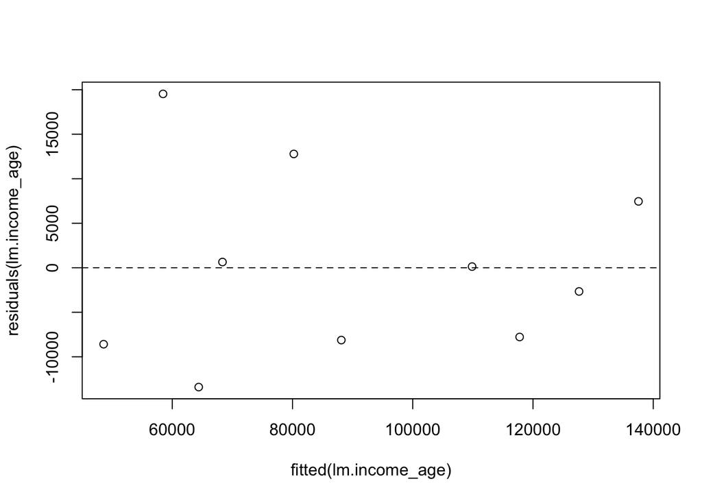

```r
plot(fitted(lm.income_age), residuals(lm.income_age))

abline(h = 0, lty = 2)
```

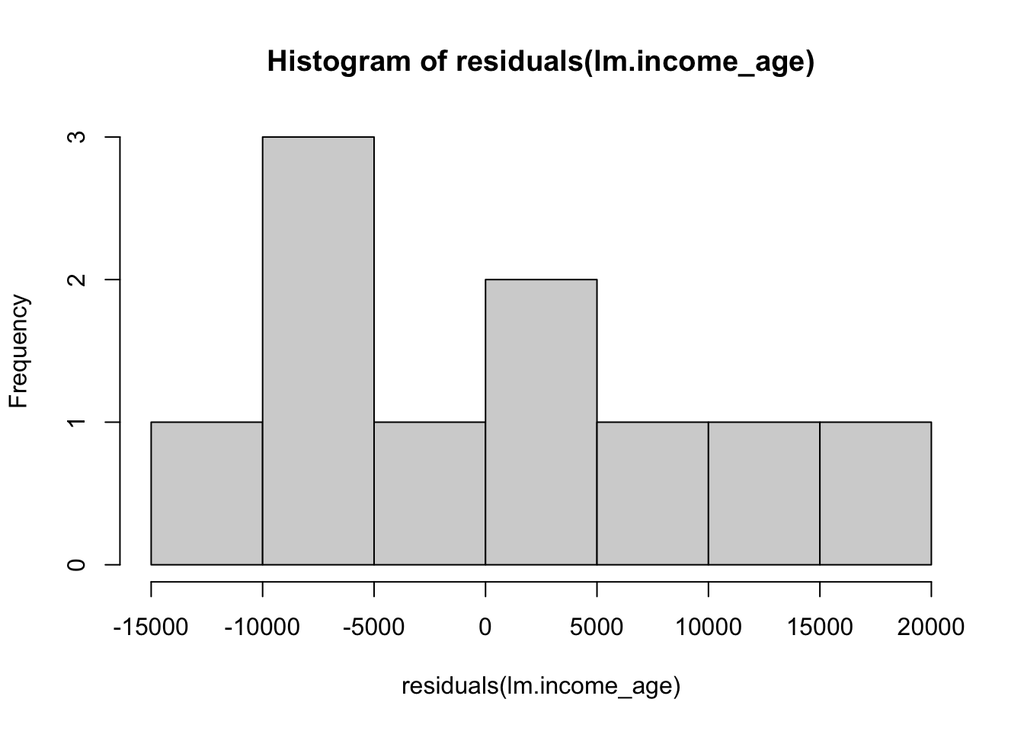

```r
hist(residuals(lm.income_age))
```

## Q1b (10 points)

Plot the income as a function of age using a scatterplot and draw the least-square line on the same plot.

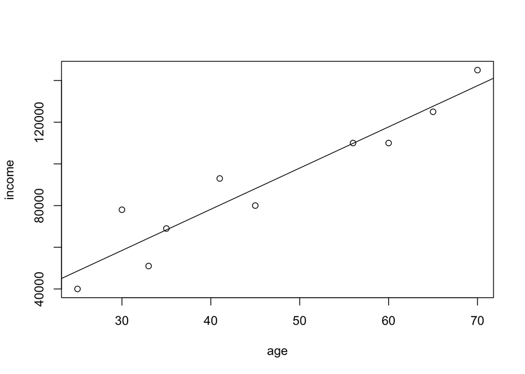

```
## integer(0)
```

```r
#INSERT YOUR ANSWER HERE
# least-squares line plot
plot(age, income) + abline(lm(income ~ age))
```

## Q1c (10 points)

Use the regression line to predict the income when the age is 38.

```r
#INSERT YOUR ANSWER HERE
newdata <- data.frame(age=38)

model <- lm(income ~ age)

predict(model, newdata = newdata)
```

```
##        1
## 74285.22
```

# Question 2 [45 Pts]

Please load the OpenIntro Statistics Dataset - loans_full_schema data by running the following chunk of code.

You can read more about at this link: - https://r-data.pmagunia.com/dataset/openintro-statistics-dataset-loansfullschema - https://www.openintro.org/data/index.php?data=loans_full_schema

```r
OpenIntro = read.csv("https://www.openintro.org/data/csv/loans_full_schema.csv")
```

## Q2a (5 points)

Display the first 5 rows of the `OpenIntro` data, the names of all the variables, and a descriptive summary of each variable.

```r
#INSERT YOUR ANSWER HERE
# first 5 rows
head(OpenIntro)
```

```
##                 emp_title emp_length state homeownership annual_income
## 1 global config engineer           3    NJ      MORTGAGE         90000
## 2  warehouse office clerk         10    HI          RENT         40000
## 3                assembly          3    WI          RENT         40000
## 4        customer service          1    PA          RENT         30000
## 5    security supervisor          10    CA          RENT         35000
## 6                                 NA    KY           OWN         34000
##   verified_income debt_to_income annual_income_joint verification_income_joint
## 1        Verified          18.01                  NA
## 2    Not Verified           5.04                  NA
## 3 Source Verified          21.15                  NA
## 4    Not Verified          10.16                  NA
## 5        Verified          57.96               57000                  Verified
## 6    Not Verified           6.46                  NA
##   debt_to_income_joint delinq_2y months_since_last_delinq earliest_credit_line
```

[output cut: 97 more lines]

```r
# names of all variables
names(OpenIntro)
```

```
##  [1] "emp_title"                        "emp_length"
##  [3] "state"                            "homeownership"
##  [5] "annual_income"                    "verified_income"
##  [7] "debt_to_income"                   "annual_income_joint"
##  [9] "verification_income_joint"        "debt_to_income_joint"
## [11] "delinq_2y"                        "months_since_last_delinq"
## [13] "earliest_credit_line"             "inquiries_last_12m"
## [15] "total_credit_lines"               "open_credit_lines"
## [17] "total_credit_limit"               "total_credit_utilized"
## [19] "num_collections_last_12m"         "num_historical_failed_to_pay"
## [21] "months_since_90d_late"            "current_accounts_delinq"
## [23] "total_collection_amount_ever"     "current_installment_accounts"
## [25] "accounts_opened_24m"              "months_since_last_credit_inquiry"
## [27] "num_satisfactory_accounts"        "num_accounts_120d_past_due"
## [29] "num_accounts_30d_past_due"        "num_active_debit_accounts"
## [31] "total_debit_limit"                "num_total_cc_accounts"
## [33] "num_open_cc_accounts"             "num_cc_carrying_balance"
## [35] "num_mort_accounts"                "account_never_delinq_percent"
## [37] "tax_liens"                        "public_record_bankrupt"
## [39] "loan_purpose"                     "application_type"
## [41] "loan_amount"                      "term"
## [43] "interest_rate"                    "installment"
## [45] "grade"                            "sub_grade"
## [47] "issue_month"                      "loan_status"
## [49] "initial_listing_status"           "disbursement_method"
## [51] "balance"                          "paid_total"
## [53] "paid_principal"                   "paid_interest"
## [55] "paid_late_fees"
```

```r
# descriptive summary of each variable
summary(OpenIntro)
```

```
##   emp_title           emp_length       state           homeownership
##  Length:10000       Min.   : 0.00   Length:10000       Length:10000
##  Class :character   1st Qu.: 2.00   Class :character   Class :character
##  Mode  :character   Median : 6.00   Mode  :character   Mode  :character
##                     Mean   : 5.93
##                     3rd Qu.:10.00
##                     Max.   :10.00
##                     NA's   :817
##  annual_income     verified_income    debt_to_income   annual_income_joint
##  Min.   :      0   Length:10000       Min.   :  0.00   Min.   :  19200
##  1st Qu.:  45000   Class :character   1st Qu.: 11.06   1st Qu.:  86834
##  Median :  65000   Mode  :character   Median : 17.57   Median : 113000
##  Mean   :  79222                      Mean   : 19.31   Mean   : 127915
##  3rd Qu.:  95000                      3rd Qu.: 25.00   3rd Qu.: 151546
##  Max.   :2300000                      Max.   :469.09   Max.   :1100000
##                                       NA's   :24       NA's   :8505
##  verification_income_joint debt_to_income_joint   delinq_2y
##  Length:10000              Min.   : 0.32        Min.   : 0.000
##  Class :character          1st Qu.:14.16        1st Qu.: 0.000
##  Mode  :character          Median :19.72        Median : 0.000
##                            Mean   :19.98        Mean   : 0.216
##                            3rd Qu.:25.50        3rd Qu.: 0.000
##                            Max.   :39.98        Max.   :13.000
##                            NA's   :8505
##  months_since_last_delinq earliest_credit_line inquiries_last_12m
##  Min.   :  1.00           Min.   :1963         Min.   : 0.000
##  1st Qu.: 19.00           1st Qu.:1997         1st Qu.: 0.000
##  Median : 34.00           Median :2003         Median : 1.000
##  Mean   : 36.76           Mean   :2001         Mean   : 1.958
##  3rd Qu.: 53.00           3rd Qu.:2006         3rd Qu.: 3.000
##  Max.   :118.00           Max.   :2015         Max.   :29.000
##  NA's   :5658
##  total_credit_lines open_credit_lines total_credit_limit total_credit_utilized
##  Min.   : 2.00      Min.   : 0.0      Min.   :      0    Min.   :     0
##  1st Qu.:14.00      1st Qu.: 7.0      1st Qu.:  51594    1st Qu.: 19186
##  Median :21.00      Median :10.0      Median : 114667    Median : 36927
##  Mean   :22.68      Mean   :11.4      Mean   : 183606    Mean   : 51049
##  3rd Qu.:29.00      3rd Qu.:14.0      3rd Qu.: 267550    3rd Qu.: 65421
##  Max.   :87.00      Max.   :51.0      Max.   :3386034    Max.   :942456
##
```

[output cut: 81 more lines]

```
##  Length:10000           Length:10000        Min.   :    0   Min.   :    0.0
##  Class :character       Class :character    1st Qu.: 6679   1st Qu.:  928.7
##  Mode  :character       Mode  :character    Median :12380   Median : 1563.3
##                                             Mean   :14459   Mean   : 2494.2
##                                             3rd Qu.:20690   3rd Qu.: 2616.0
##                                             Max.   :40000   Max.   :41630.4
##
##  paid_principal    paid_interest    paid_late_fees
##  Min.   :    0.0   Min.   :   0.0   Min.   : 0.0000
##  1st Qu.:  587.1   1st Qu.: 221.8   1st Qu.: 0.0000
##  Median :  985.0   Median : 446.1   Median : 0.0000
##  Mean   : 1894.5   Mean   : 599.7   Mean   : 0.1195
##  3rd Qu.: 1694.6   3rd Qu.: 825.4   3rd Qu.: 0.0000
##  Max.   :40000.0   Max.   :4216.4   Max.   :52.9800
##
```

## Q2b (5 points)

Calculate the mean, variance and standard deviation of the interest rate of the loans (`interest_rate`) by omitting the missing values, if any.

```r
#INSERT YOUR ANSWER HERE
# mean of interest rate of loans
mean(OpenIntro$interest_rate, na.rm = T)
```

```
## [1] 12.42752
```

```r
# variance of interest rate of loans
var(OpenIntro$interest_rate, na.rm = T)
```

```
## [1] 25.01105
```

```r
# standard deviation of interest rate of loans
sd(OpenIntro$interest_rate, na.rm = T)
```

```
## [1] 5.001105
```

## Q2c-1 (5 points)

Use annual income (`annual_income`), the length of the loan (`term`), interest rate (`interest_rate`), and loan ammount (`loan_amount`) to build a linear regression model to predict Monthly payment for the loan the applicant received. (`installment`).

## Q2c-2 (5 points)

How can you draw a conclusion from the results? (Note: Full marks requires comment on the predictors)

```r
#INSERT YOUR ANSWER HERE
# Q2c-1
multiple_model <- lm(installment ~ annual_income + term + interest_rate + loan_amount, data = OpenIntro)

summary(multiple_model)
```

```
##
## Call:
## lm(formula = installment ~ annual_income + term + interest_rate +
##     loan_amount, data = OpenIntro)
##
## Residuals:
##      Min       1Q   Median       3Q      Max
## -222.235  -20.245    6.478   20.368  235.867
##
## Coefficients:
##                 Estimate Std. Error  t value Pr(>|t|)
## (Intercept)    2.529e+02  2.036e+00  124.193   <2e-16 ***
## annual_income  7.824e-06  7.661e-06    1.021    0.307
## term          -8.836e+00  4.881e-02 -181.020   <2e-16 ***
## interest_rate  8.799e+00  1.004e-01   87.621   <2e-16 ***
## loan_amount    3.030e-02  5.166e-05  586.440   <2e-16 ***
## ---
## Signif. codes:  0 '***' 0.001 '**' 0.01 '*' 0.05 '.' 0.1 ' ' 1
##
## Residual standard error: 46.47 on 9995 degrees of freedom
## Multiple R-squared:  0.9752, Adjusted R-squared:  0.9752
## F-statistic: 9.813e+04 on 4 and 9995 DF,  p-value: < 2.2e-16
```

```r
#install.packages("car")
library(car)
```

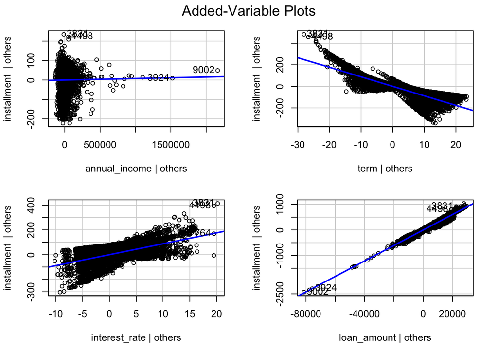

```r
avPlots(multiple_model)
```

```r
#Q2c-2

# The p-value for each of the predictors apart from annual_income are quite low so that means that they are statistically significant enough to explain the variation in the installment variable.
# The model fit is 97.52% so the model fits the data really well.
```